# AVIATION ACCIDENTS

## Business Understanding

### Problem Statement

The aviation industry may be able to improve safety measures by analyzing accident data to identify patterns in aircraft damage and fatality rates. Doing so will allow airlines, manufacturers, and regulatory agencies to better understand risk factors and implement strategies to enhance aviation safety. Using aircraft accident data, I will examine key trends to determine which aircraft models demonstrate strong safety records and provide actionable insights for improving aviation safety standards.

### Business Objectives

1.Which aircraft models have the highest fatality rates?

2.Try and find the leading cause of aviation accidents?

3.Trends in aviation fatalities over the years?

4.Recomend actions to help mitigate/prevent aviation accidents and incedents?

## Data Understanding

```python
import pandas as pd
import numpy as np
import matplotlib.pyplot as plt
```

```python
df = pd.read_csv("aviation-accident-data-2023-05-16.csv")
df.head()
```

|  | date | type | registration | operator | fatalities | location | country | cat | year |
| --- | --- | --- | --- | --- | --- | --- | --- | --- | --- |
| 0 | date unk. | Antonov An-12B | T-1206 | Indonesian AF | NaN | NaN | Unknown country | U1 | unknown |
| 1 | date unk. | Antonov An-12B | T-1204 | Indonesian AF | NaN | NaN | Unknown country | U1 | unknown |
| 2 | date unk. | Antonov An-12B | T-1201 | Indonesian AF | NaN | NaN | Unknown country | U1 | unknown |
| 3 | date unk. | Antonov An-12BK | NaN | Soviet AF | NaN | Tiksi Airport (IKS) | Russia | A1 | unknown |
| 4 | date unk. | Antonov An-12BP | CCCP-11815 | Soviet AF | 0 | Massawa Airport ... | Eritrea | A1 | unknown |

```python
df.info()
```

```
<class 'pandas.core.frame.DataFrame'>
RangeIndex: 23967 entries, 0 to 23966
Data columns (total 9 columns):
 #   Column        Non-Null Count  Dtype
---  ------        --------------  -----
 0   date          23967 non-null  object
 1   type          23967 non-null  object
 2   registration  22419 non-null  object
 3   operator      23963 non-null  object
 4   fatalities    20029 non-null  object
 5   location      23019 non-null  object
 6   country       23967 non-null  object
 7   cat           23967 non-null  object
 8   year          23967 non-null  object
dtypes: object(9)
memory usage: 1.6+ MB
```

```python
df.describe()
```

|  | date | type | registration | operator | fatalities | location | country | cat | year |
| --- | --- | --- | --- | --- | --- | --- | --- | --- | --- |
| count | 23967 | 23967 | 22419 | 23963 | 20029 | 23019 | 23967 | 23967 | 23967 |
| unique | 15079 | 3201 | 21962 | 6017 | 369 | 14608 | 232 | 11 | 106 |
| top | 10-MAY-1940 | Douglas C-47A (DC-3) | LZ-... | USAAF | 0 | unknown | USA | A1 | 1944 |
| freq | 171 | 1916 | 13 | 2604 | 10713 | 272 | 4377 | 17424 | 1505 |

```python
df.shape
```

```
(23967, 9)
```

## Data Preparation

#### Data Cleaning

```python
# check for duplicated values
df.duplicated().value_counts()
```

```
False    23852
True       115
dtype: int64
```

```python
 #View duplicates
df[df.duplicated()].head(15)
```

|  | date | type | registration | operator | fatalities | location | country | cat | year |
| --- | --- | --- | --- | --- | --- | --- | --- | --- | --- |
| 542 | 13-APR-1940 | Junkers Ju-52/3m | NaN | German AF | NaN | Gangsoya, Sogn o... | Norway | A1 | 1940 |
| 560 | 29-APR-1940 | Junkers Ju-52/3m | NaN | German AF | 0 | Oslo-Fornebu Air... | Norway | A1 | 1940 |
| 568 | 10-MAY-1940 | Junkers Ju-52/3m | NaN | German AF | NaN | Waalhaven | Netherlands | A1 | 1940 |
| 577 | 10-MAY-1940 | Junkers Ju-52/3m | NaN | German AF | NaN | near Den Haag | Netherlands | A1 | 1940 |
| 579 | 10-MAY-1940 | Junkers Ju-52/3m | NaN | German AF | NaN | Waalhaven | Netherlands | A1 | 1940 |
| 580 | 10-MAY-1940 | Junkers Ju-52/3m | NaN | German AF | NaN | near Den Haag | Netherlands | A1 | 1940 |
| 581 | 10-MAY-1940 | Junkers Ju-52/3m | NaN | German AF | NaN | near Den Haag | Netherlands | A1 | 1940 |
| 582 | 10-MAY-1940 | Junkers Ju-52/3m | NaN | German AF | NaN | near Den Haag | Netherlands | A1 | 1940 |
| 584 | 10-MAY-1940 | Junkers Ju-52/3m | NaN | German AF | NaN | Waalhaven | Netherlands | A1 | 1940 |
| 585 | 10-MAY-1940 | Junkers Ju-52/3m | NaN | German AF | NaN | near Den Haag | Netherlands | A1 | 1940 |
| 587 | 10-MAY-1940 | Junkers Ju-52/3m | NaN | German AF | NaN | near Den Haag | Netherlands | A1 | 1940 |
| 588 | 10-MAY-1940 | Junkers Ju-52/3m | NaN | German AF | NaN | near Den Haag | Netherlands | A1 | 1940 |
| 589 | 10-MAY-1940 | Junkers Ju-52/3m | NaN | German AF | NaN | Waalhaven | Netherlands | A1 | 1940 |
| 590 | 10-MAY-1940 | Junkers Ju-52/3m | NaN | German AF | NaN | Waalhaven | Netherlands | A1 | 1940 |
| 605 | 10-MAY-1940 | Junkers Ju-52/3m | NaN | German AF | NaN | Waalhaven | Netherlands | A1 | 1940 |

```python
# removing  duplicated values
df = df.drop_duplicates()
```

```python
# verify that they have been removed

df.duplicated().value_counts()
```

```
False    23852
dtype: int64
```

```python
# gives the columns names in the dataset
df.columns
```

```
Index(['date', 'type', 'registration', 'operator', 'fatalities', 'location',
       'country', 'cat', 'year'],
      dtype='object')
```

### Dealing with missing values

#### Detecting Null Values

```python
# detecting null  values
#isnull

df.isna().sum()
```

```
date               0
type               0
registration    1434
operator           4
fatalities      3833
location         932
country            0
cat                0
year               0
dtype: int64
```

### Handling missing values

```python
df["operator"] = df["operator"].fillna("Unknown")
df.isna().sum()
```

```
date               0
type               0
registration    1434
operator           0
fatalities      3833
location         932
country            0
cat                0
year               0
dtype: int64
```

```python
df["fatalities"] = df["fatalities"].fillna("no fatalities")
df.isna().sum()
```

```
date               0
type               0
registration    1434
operator           0
fatalities         0
location         932
country            0
cat                0
year               0
dtype: int64
```

```python
df["location"] = df["operator"].fillna("unknown location")
df.isna().sum()
```

```
date               0
type               0
registration    1434
operator           0
fatalities         0
location           0
country            0
cat                0
year               0
dtype: int64
```

```python
df["registration"] = df["registration"].fillna("no registeration")
df.isna().sum()
```

```
date            0
type            0
registration    0
operator        0
fatalities      0
location        0
country         0
cat             0
year            0
dtype: int64
```

## Data Analysis

Objective 1 : Which aircraft models have the highest fatality rates?

```python
df["fatalities"] = pd.to_numeric(df["fatalities"], errors="coerce")
```

```python
# Using groupby
top_fatal_models = df.groupby("type")["fatalities"].sum().sort_values(ascending=False).head(10)
```

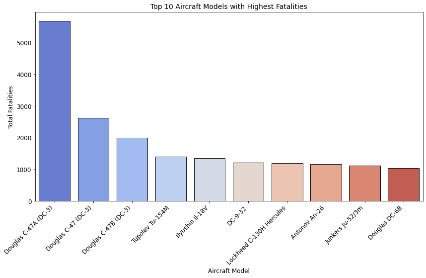

```python
import seaborn as sns
import matplotlib.pyplot as plt
plt.figure(figsize=(14, 7))
ax = sns.barplot(x=top_fatal_models.index, y=top_fatal_models.values, palette="coolwarm", edgecolor="black")
plt.xticks(rotation=45, ha="right", fontsize=12)
plt.yticks(fontsize=12)
plt.title("Top 10 Aircraft Models with Highest Fatalities", fontsize=14)
plt.xlabel("Aircraft Model", fontsize=12)
plt.ylabel("Total Fatalities", fontsize=12)
plt.show()
```

```python
# Calcuate fatality rate per model
df["fatalities"] = pd.to_numeric(df["fatalities"], errors="coerce")
accident_counts = df.groupby("type")["fatalities"].count()
# Sum total fatalities per model
fatality_sums = df.groupby("type")["fatalities"].sum()
fatality_rate = (fatality_sums / accident_counts).sort_values(ascending=False).head(10)
```

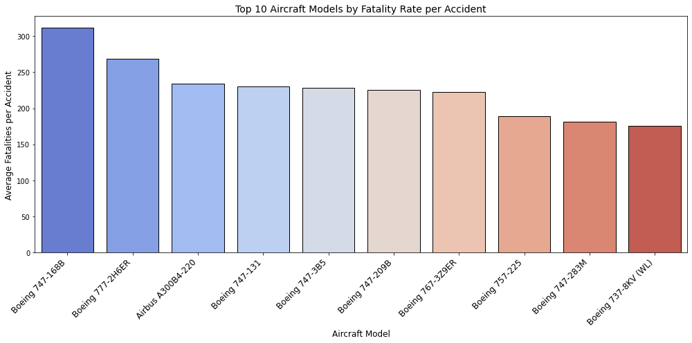

```python
plt.figure(figsize=(14, 7))
ax = sns.barplot(x=fatality_rate.index, y=fatality_rate.values, palette="coolwarm", edgecolor="black")
plt.title("Top 10 Aircraft Models by Fatality Rate per Accident", fontsize=14)
plt.xticks(rotation=45, ha="right", fontsize=12)
plt.xlabel("Aircraft Model", fontsize=12)
plt.ylabel("Average Fatalities per Accident", fontsize=12)
plt.tight_layout()
plt.show()
```

Douglas C47-A also has significant fatalities (is an older generation model tending to have higher accident rates due to outdated systems)

Objective 2 :Try and find the leading cause of aviation accidents?

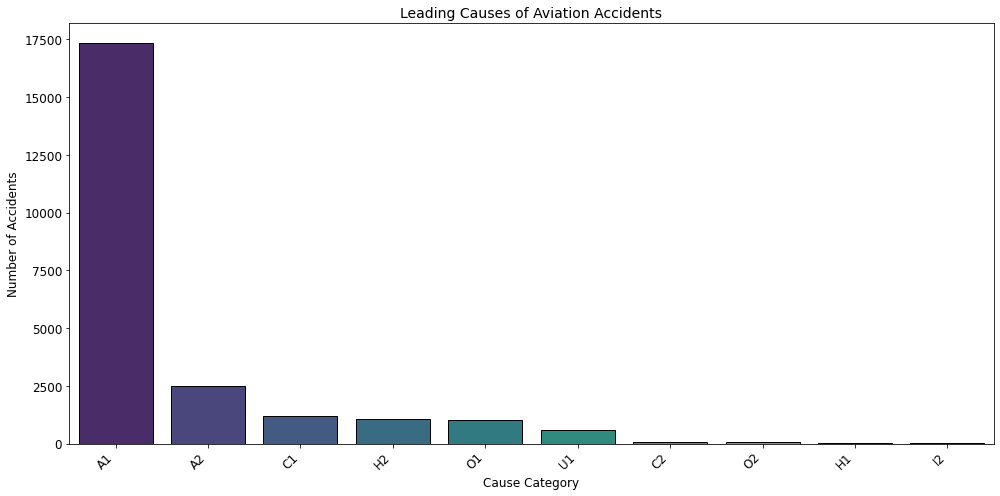

```python
import matplotlib.pyplot as plt
import seaborn as sns

# Count number of accidents by cause
leading_causes = df["cat"].value_counts().head(10)

# Plotting
plt.figure(figsize=(14, 7))
sns.barplot(x=leading_causes.index, y=leading_causes.values, palette="viridis", edgecolor="black")

# Customize labels
plt.xticks(rotation=45, ha="right", fontsize=12)
plt.yticks(fontsize=12)
plt.title("Leading Causes of Aviation Accidents", fontsize=14)
plt.xlabel("Cause Category", fontsize=12)
plt.ylabel("Number of Accidents", fontsize=12)
plt.tight_layout()

plt.show()
```

```python
# See all unique values in the 'cat' column
print(df["cat"].unique())
```

```
['U1' 'A1' 'A2' 'O1' 'H2' 'C1' 'C2' 'H1' 'O2' 'I2' 'I1']
```

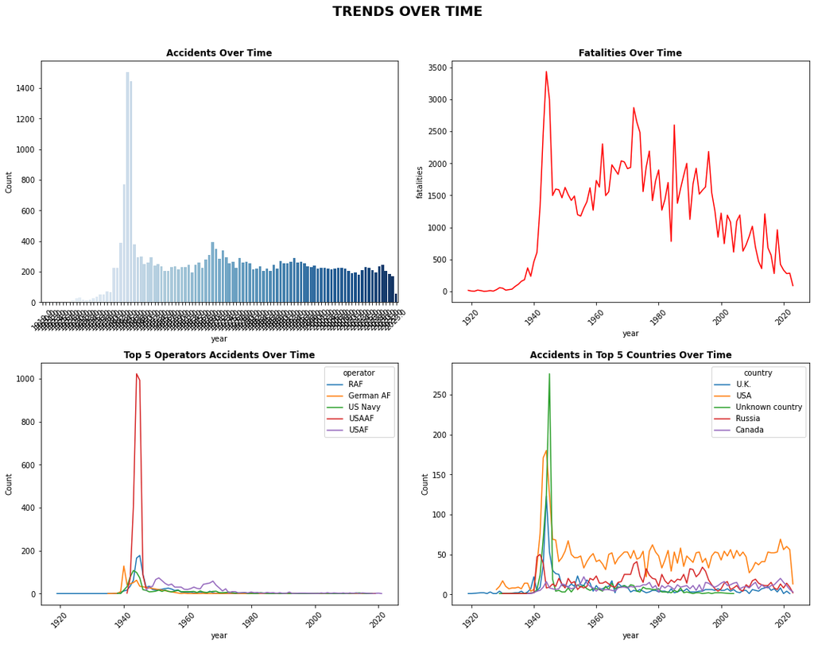

```python
import matplotlib.pyplot as plt
import seaborn as sns
import pandas as pd

# Make sure year is numeric
df['year'] = pd.to_numeric(df['year'], errors='coerce')

# Create figure and axes
fig, axes = plt.subplots(2, 2, figsize=(15, 12))
fig.suptitle('TRENDS OVER TIME', fontsize=18, fontweight='bold')

# 1st Plot: Number of accidents per year
accidents_per_year = df.groupby('year').size().reset_index(name='Count')
sns.barplot(x='year', y='Count', data=accidents_per_year, ax=axes[0, 0], palette='Blues')
axes[0, 0].set_title("Accidents Over Time", fontweight='bold')
axes[0, 0].tick_params(axis='x', rotation=45)

# 2nd Plot: Fatalities per year
fatalities_per_year = df.groupby('year')['fatalities'].sum().reset_index()
sns.lineplot(x='year', y='fatalities', data=fatalities_per_year, ax=axes[0, 1], color='red')
axes[0, 1].set_title("Fatalities Over Time", fontweight='bold')
axes[0, 1].tick_params(axis='x', rotation=45)

# 3rd Plot: Top 5 operators with most accidents over time
top_5_operators = df['operator'].value_counts().head(5).index
df_top_ops = df[df['operator'].isin(top_5_operators)]
ops_trends = df_top_ops.groupby(['year', 'operator']).size().reset_index(name='Count')
sns.lineplot(x='year', y='Count', hue='operator', data=ops_trends, ax=axes[1, 0])
axes[1, 0].set_title("Top 5 Operators Accidents Over Time", fontweight='bold')
axes[1, 0].tick_params(axis='x', rotation=45)

# 4th Plot: Accidents by country over time (top 5)
top_5_countries = df['country'].value_counts().head(5).index
df_top_countries = df[df['country'].isin(top_5_countries)]
country_trends = df_top_countries.groupby(['year', 'country']).size().reset_index(name='Count')
sns.lineplot(x='year', y='Count', hue='country', data=country_trends, ax=axes[1, 1])
axes[1, 1].set_title("Accidents in Top 5 Countries Over Time", fontweight='bold')
axes[1, 1].tick_params(axis='x', rotation=45)

# Adjust layout and show
plt.tight_layout(rect=[0, 0, 1, 0.96])
plt.show()
```

The cat column in aviation accident datasets typically stands for category or cause category of the accident.